# Black Friday - eine statistische Analyse der Verkaufszahlen

# Projektarbeit für Algorithmik & Statistik für Data Science 2 Lab

## Black Friday - eine statistische Analyse der Verkaufszahlen

Christoph Rabensteiner: 1810837995

Valentin Muhr: 1810837102

Magdalena Breu: 1810837995

Jochen Paul Hollich: 1810837475

# Einleitung

## Hintergrundinformationen zum Datensatz

Der Datensatz wurde bereitgestellt durch einen [Hackathon der Firma AnalyticsVidhya](https://datahack.analyticsvidhya.com/contest/black-friday/) und heruntergeladen über [Kaggle.com](https://www.kaggle.com/mehdidag/black-friday).

## Aufbau dieser Arbeit

Unser Ziel ist es das Konsumverhalten der Kunden genauer zu analysieren. Dafür schauen wir uns als erstes die Daten genauer an und versuchen anhand der erstellten Plots, die Zusammenhänge zwischen den einzelnen Variablen zu erkennen.

Auf diesem Wissen aufbauend werden wir verschiedene ausgewählte Modelle berechnen und analysieren. Mit dem Modellen möchten wir die Ausgaben der Kunden anhand der Prädiktoren vorhersagen können.

# Laden der Daten

```r
set.seed(10091212)
bf <- read.csv2("BlackFriday.csv", dec=".", header=TRUE, sep=",")
```

Struktur der Daten: Die Funktion str() gibt viele nützliche Informationen zurück, einschließlich den Dimensionen des Dataframes, die enthaltenen Feature Namen, deren Datentype und die ersten 10 Beobachtungen pro Feature. In diesem Beispiel bedeutet “int”, dass die Variable “User_ID” eine ganze Zahl ist, und “Factor” bedeutet, dass die Variable “Product_ID” mit 3623 Kategorien oder Ebenen kategorisch ist.

```r
str(bf)
```

```
## 'data.frame':    537577 obs. of  12 variables:
##  $ User_ID                   : int  1000001 1000001 1000001 1000001 1000002 1000003 1000004 1000004 1000004 1000005 ...
##  $ Product_ID                : Factor w/ 3623 levels "P00000142","P00000242",..: 671 2375 851 827 2733 1830 1744 3319 3597 2630 ...
##  $ Gender                    : Factor w/ 2 levels "F","M": 1 1 1 1 2 2 2 2 2 2 ...
##  $ Age                       : Factor w/ 7 levels "0-17","18-25",..: 1 1 1 1 7 3 5 5 5 3 ...
##  $ Occupation                : int  10 10 10 10 16 15 7 7 7 20 ...
##  $ City_Category             : Factor w/ 3 levels "A","B","C": 1 1 1 1 3 1 2 2 2 1 ...
##  $ Stay_In_Current_City_Years: Factor w/ 5 levels "0","1","2","3",..: 3 3 3 3 5 4 3 3 3 2 ...
##  $ Marital_Status            : int  0 0 0 0 0 0 1 1 1 1 ...
##  $ Product_Category_1        : int  3 1 12 12 8 1 1 1 1 8 ...
##  $ Product_Category_2        : int  NA 6 NA 14 NA 2 8 15 16 NA ...
##  $ Product_Category_3        : int  NA 14 NA NA NA NA 17 NA NA NA ...
##  $ Purchase                  : int  8370 15200 1422 1057 7969 15227 19215 15854 15686 7871 ...
```

Zusammenfassung der Daten: Die Funktion summary() wird im Wesentlichen auf jede Spalte eines Data Frames angewendetund und die Ergebnisse werden für alle Spalten werden gemeinsam angezeigt. Für die Integer Variablen gibt die Funktion die Auflistung in Minimum, 1. Quantile, Median, Mean, 3. Quantile und Maximum zurück. Würden NA Werte auftreten, wie für die Variable “Product_Categorie_2”“, dann werden auch diese als Summe aufgelistet. Für eine kategorische Variable wie”Product_ID" werden die Ebenen und die Anzahl der Daten in jeder Ebene zurückgegeben.

```r
summary(bf)
```

```
##     User_ID            Product_ID     Gender        Age
##  Min.   :1000001   P00265242:  1858   F:132197   0-17 : 14707
##  1st Qu.:1001495   P00110742:  1591   M:405380   18-25: 97634
##  Median :1003031   P00025442:  1586              26-35:214690
##  Mean   :1002992   P00112142:  1539              36-45:107499
##  3rd Qu.:1004417   P00057642:  1430              46-50: 44526
##  Max.   :1006040   P00184942:  1424              51-55: 37618
##                    (Other)  :528149              55+  : 20903
##    Occupation     City_Category Stay_In_Current_City_Years
##  Min.   : 0.000   A:144638      0 : 72725
##  1st Qu.: 2.000   B:226493      1 :189192
##  Median : 7.000   C:166446      2 : 99459
##  Mean   : 8.083                 3 : 93312
##  3rd Qu.:14.000                 4+: 82889
##  Max.   :20.000
##
##  Marital_Status   Product_Category_1 Product_Category_2 Product_Category_3
##  Min.   :0.0000   Min.   : 1.000     Min.   : 2.00      Min.   : 3.0
##  1st Qu.:0.0000   1st Qu.: 1.000     1st Qu.: 5.00      1st Qu.: 9.0
##  Median :0.0000   Median : 5.000     Median : 9.00      Median :14.0
##  Mean   :0.4088   Mean   : 5.296     Mean   : 9.84      Mean   :12.7
##  3rd Qu.:1.0000   3rd Qu.: 8.000     3rd Qu.:15.00      3rd Qu.:16.0
##  Max.   :1.0000   Max.   :18.000     Max.   :18.00      Max.   :18.0
##                                      NA's   :166986     NA's   :373299
##     Purchase
##  Min.   :  185
##  1st Qu.: 5866
##  Median : 8062
##  Mean   : 9334
##  3rd Qu.:12073
##  Max.   :23961
##
```

## Beschreibung der Daten:

In der Tabelle gibt es insgesamt 12 verschiedene Variablen, die folgend erklärt werden:

`User_ID`: eindeutige ID eines Kunden

`Product_ID`: eindeutige ID eines Produktes

`Gender`: Geschlecht des Kunden

`Age`: Altersgruppe des Kunden

`Occupation`: Beschäftigungsgruppe des Kunden

`City_Category`: Wohnort des Kunden

`Stay_In_Current_City_Yeas`: Anzahl der Jahre seitdem der Kunde in der Stadt wohnt

`Marital_Status`: Ehestatus

`Product_Category_1`: Produktkategorie des Einkaufs

`Product_Category_2`: Produkt könnte dieser Kategorie angehören

`Product_Category_3`: Produkt könnte dieser Kategorie angehören

`Purchase`: Summe des Einkaufs: Hierzu fehlt leider gänzlich die Information um die Währung. Wir nehmen an, dass das Dollar Summen sind, obwohl uns diese ersichtlich hoch vorkommen. Der Maximal Wert liegt hier bei 23.961$. Wir vermuten dennoch, dass es sich hierbei um Ausreißer in im amerikanischen Black Firday Markt handelt und vereinzelt auch vorkommen kann.

# Bereinigung der Daten

Im Folgenden überprüfen wir die Anazhl der NAs je Feature.

```
##  [1]      0      0      0      0      0      0      0      0      0      0
## [11] 166986 373299      0
```

Bei der Überprüfung der NAs fällt uns auf, dass wir nur in der Product Category 2 & 3 NA-Werte enthalten haben. In der Beschreibung zum Datensatz befinden sich keine Informatione dazu, wie die NA-Werte zu interpretieren sind. Nach Betrachtung der Daten haben wir folgende Annhame getroffen: Sind NA in einem Sample enthalten, gehen wir davon aus, dass von dieser Produktkategorie kein Produkt gekauft wurde. Das konnten wir überprüfen, da es keine “0” Werte in Category 2 & 3 gibt. Somit nehmen wir an, dass die NA-Werte für “nicht gekauft” steht, und ersetzen aus diesem Grund die NA-Werte mit 0.

NA-Werte sind immer schlecht in einem Datensatz, da diese Werte die Samples unter Umständen unbrauchbar machen können. Durch das Ersetzen mit 0 können wir alle Samples behalten und auch nicht-gekaufte Produkte repräsentiern.

Zusätzlich werden die Produktkategorien von Numeric in Integer umgewandelt:

```r
bf[is.na(bf)] <- 0
bf$Product_Category_3 <- as.integer(bf$Product_Category_3)
bf$Product_Category_2 <- as.integer(bf$Product_Category_2)
```

Ausgabe der neuen Datenstruktur ohne die NULL-Werte:

```
## 'data.frame':    537577 obs. of  12 variables:
##  $ User_ID                   : int  1000001 1000001 1000001 1000001 1000002 1000003 1000004 1000004 1000004 1000005 ...
##  $ Product_ID                : Factor w/ 3623 levels "P00000142","P00000242",..: 671 2375 851 827 2733 1830 1744 3319 3597 2630 ...
##  $ Gender                    : Factor w/ 2 levels "F","M": 1 1 1 1 2 2 2 2 2 2 ...
##  $ Age                       : Factor w/ 7 levels "0-17","18-25",..: 1 1 1 1 7 3 5 5 5 3 ...
##  $ Occupation                : int  10 10 10 10 16 15 7 7 7 20 ...
##  $ City_Category             : Factor w/ 3 levels "A","B","C": 1 1 1 1 3 1 2 2 2 1 ...
##  $ Stay_In_Current_City_Years: Factor w/ 5 levels "0","1","2","3",..: 3 3 3 3 5 4 3 3 3 2 ...
##  $ Marital_Status            : int  0 0 0 0 0 0 1 1 1 1 ...
##  $ Product_Category_1        : int  3 1 12 12 8 1 1 1 1 8 ...
##  $ Product_Category_2        : int  0 6 0 14 0 2 8 15 16 0 ...
##  $ Product_Category_3        : int  0 14 0 0 0 0 17 0 0 0 ...
##  $ Purchase                  : int  8370 15200 1422 1057 7969 15227 19215 15854 15686 7871 ...
```

# Deskriptive Analyse - Die Erkundung unserer Daten.

Bevor wir mit dem Modellieren beginnen, wollen wir unsere Daten genauer betrachten und verschiedenste Analysen aufstellen.

Häufigkeiten von `User_ID`, `Product_ID` und `Occupation`:

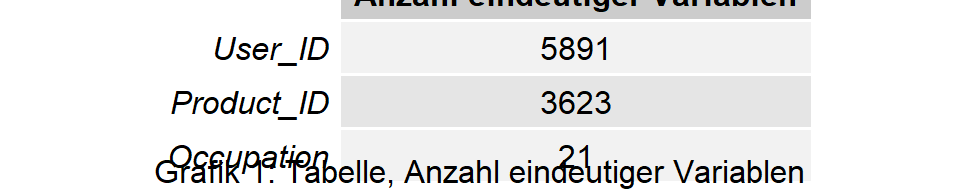

Bei der Ausgabe der Datenstruktur sehen wir, dass die USER_ID mehrmals vorkommt, d.h. ein Kunde hat auch mehrfach Einkäufe getätigt. Insgesmt haben wir zwar 537.577 verschiedene Einkäufe. Diese wurden aber von 5.891 verschiedenen Kunden getätigt. Zudem wurden insgesamt 3.623 verschiedene Artikeln gekauft. Die Kunden sind in insgesamt 21 verschiedenen Berufsgruppen zugeordnet. Wir analysieren deshalb später, welche Berufsgruppe die Konsumfreudigsten sind.

## Geschlecht

Im Folgenden sehen wir uns die Verteilung der Geschlechter genauer an.

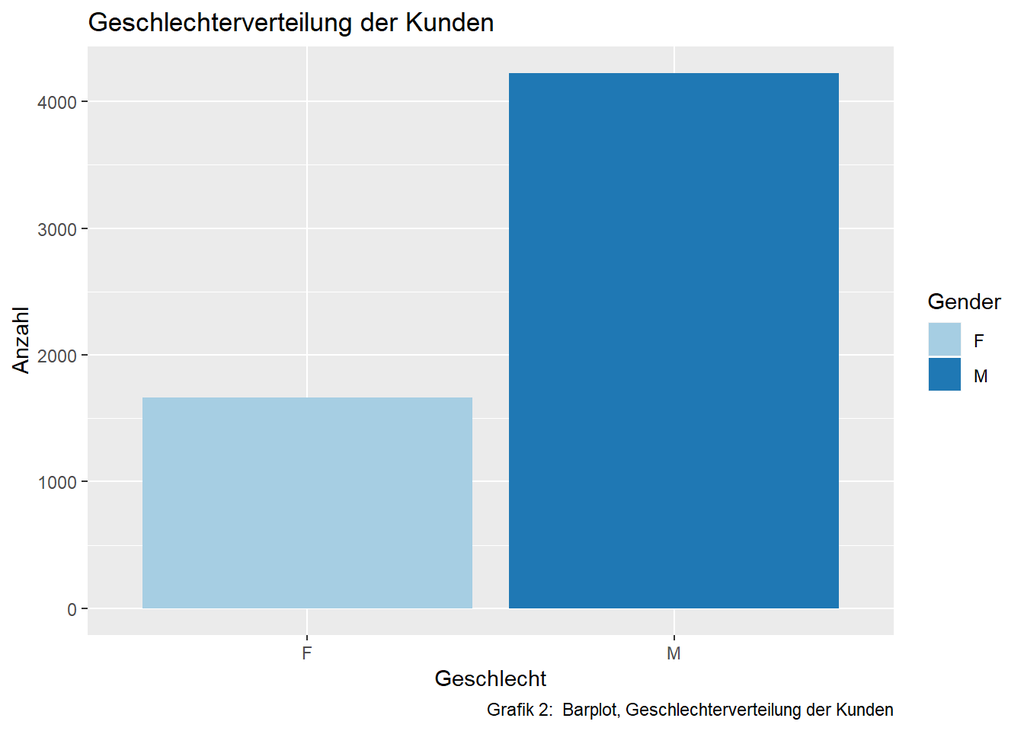

Summe der Geschlechter:

```
##    F    M
## 1666 4225
```

Wir interessieren uns auch dafür, wie die Verteilung der Warenkörbe zwischen den Geschlechten aussieht. Dafür gruppieren wir zuerst alle Einkäufe pro Kunden und geben die Summe der Einkäufe pro Geschlecht wieder:

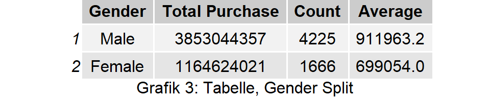

Nachfolgenden untersuchen wir den monitären Wert der Einkäufe auf die Geschlachte abgebildet:

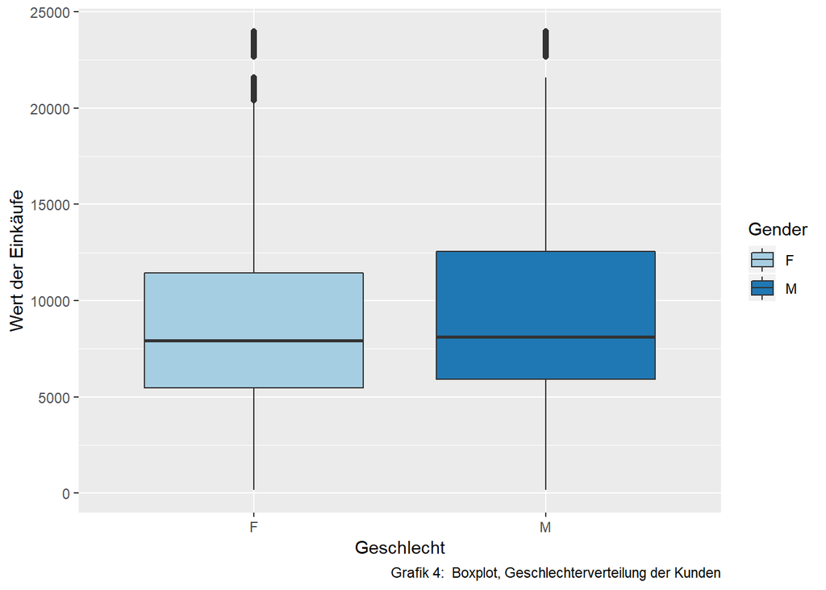

Da im Boxplot oben (Boxplot der Eikäufe nach Geschlecht) der Durchschnitt der Einkäufe je Geschlecht sehr ähnlich ist, führen wir einen t-Test durch, um zu überprüfen, ob die Verteilung der Einkäufe nach Geschlecht signifikant unterschiedlich ist. Grundsätzlich gehen wir davon aus, dass die Daten aufgrund des Grenzwertsatzes Normalverteilt sind, da es einen genügend großen Stichprobenumfang (500.000 Personen) gibt. In unserem Fall verwenden wir den Zweistichproben-t-Test um zu Überprüfen, ob der Mittelwert beider Stichproben gleich ist. Die Nullhypothese sagt hier, dass die Mittelwerte beider Gruppen gleich sind (Konfidenzintervall 95%):

```r
t.test(bf$Purchase~bf$Gender, conf.level = 0.95)
```

```
##
##  Welch Two Sample t-test
##
## data:  bf$Purchase by bf$Gender
## t = -45.673, df = 238457, p-value < 0.00000000000000022
## alternative hypothesis: true difference in means is not equal to 0
## 95 percent confidence interval:
##  -724.8357 -665.1850
## sample estimates:
## mean in group F mean in group M
##        8809.761        9504.772
```

Da der p-Wert kleiner als 0.05 ist, kann die Nullhypothese verworfen werden und es gilt, dass der Mittelwert beider Gruppen signifikant unterschiedlich ist. Wir können sagen, dass die männliche Kunden durchschnittlich mehr ausgegen als weibliche Kunden.

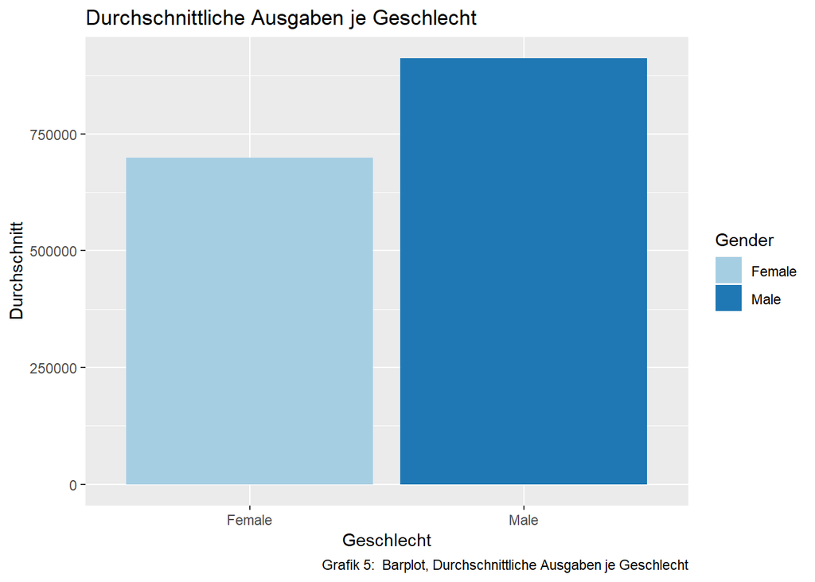

## Produkte

Auch die Produkte sehen wir uns genauer an. Als erstes geben wir die zehn häufigsten gekauften Produkte aus:

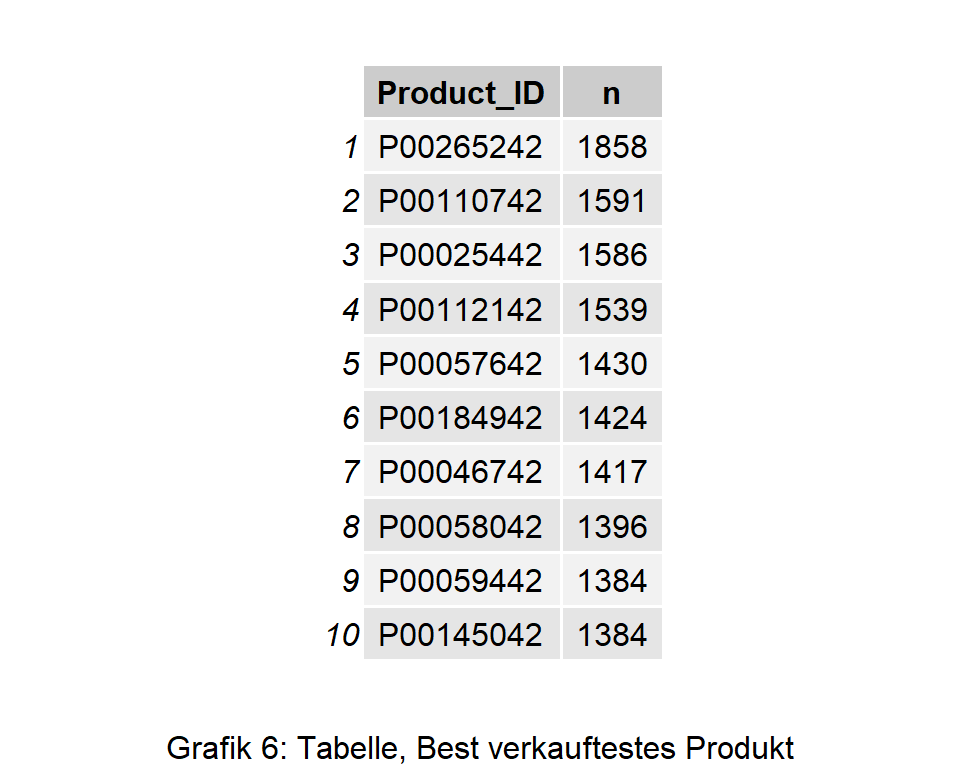

```r
bestverkaufte_Produkte = bf %>%
                          count(Product_ID, sort=T)
grid.arrange(tableGrob(head(bestverkaufte_Produkte,10)), bottom = textGrob("Grafik 6: Tabelle, Best verkauftestes Produkt"))
```

Das am meisten verkaufte Produkt ist P00265242 und zwar mit einer Anzahl von insgesamt 1.858 Stück.

```r
bestes_Produkt = bf[bf$Product_ID=='P00265242',]
head(bestes_Produkt)
```

```
##      User_ID Product_ID Gender   Age Occupation City_Category
## 400  1000066  P00265242      M 26-35         18             C
## 1192 1000196  P00265242      F 36-45          9             C
## 1373 1000222  P00265242      M 26-35          1             A
## 1846 1000301  P00265242      M 18-25          4             B
## 2210 1000345  P00265242      M 26-35         12             A
## 2405 1000383  P00265242      F 26-35          7             A
##      Stay_In_Current_City_Years Marital_Status Product_Category_1
## 400                           2              0                  5
## 1192                         4+              0                  5
## 1373                          1              0                  5
## 1846                         4+              0                  5
## 2210                          2              1                  5
## 2405                         4+              1                  5
##      Product_Category_2 Product_Category_3 Purchase
## 400                   8                  0     8652
## 1192                  8                  0     8767
## 1373                  8                  0     6944
## 1846                  8                  0     8628
## 2210                  8                  0     8593
## 2405                  8                  0     6998
```

Im weiteren betrachten wir, ob es einen Zusammenhang zum bestverkauften Produkt und den Geschlecht gibt:

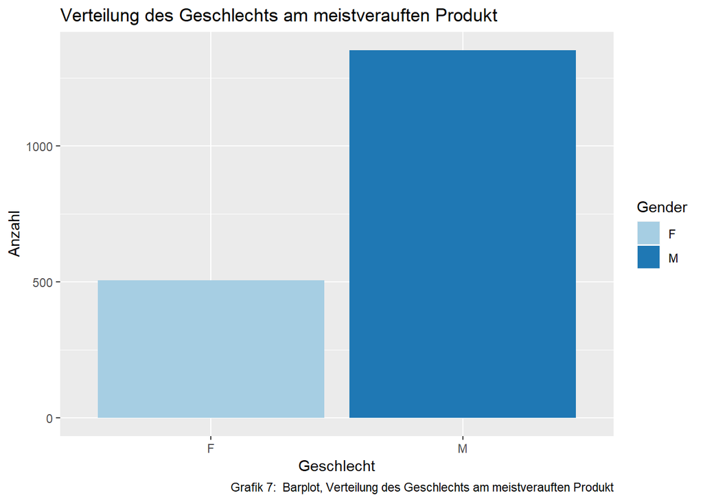

Es fällt auf, dass die Verteilung der Geschlechter am meistverkauften Produkt ähnlich aussieht, wie die Verteilung der Geschlechter auf alle Produkte. Deshalb stellen wir die Verteilungen nochmal gegenüber:

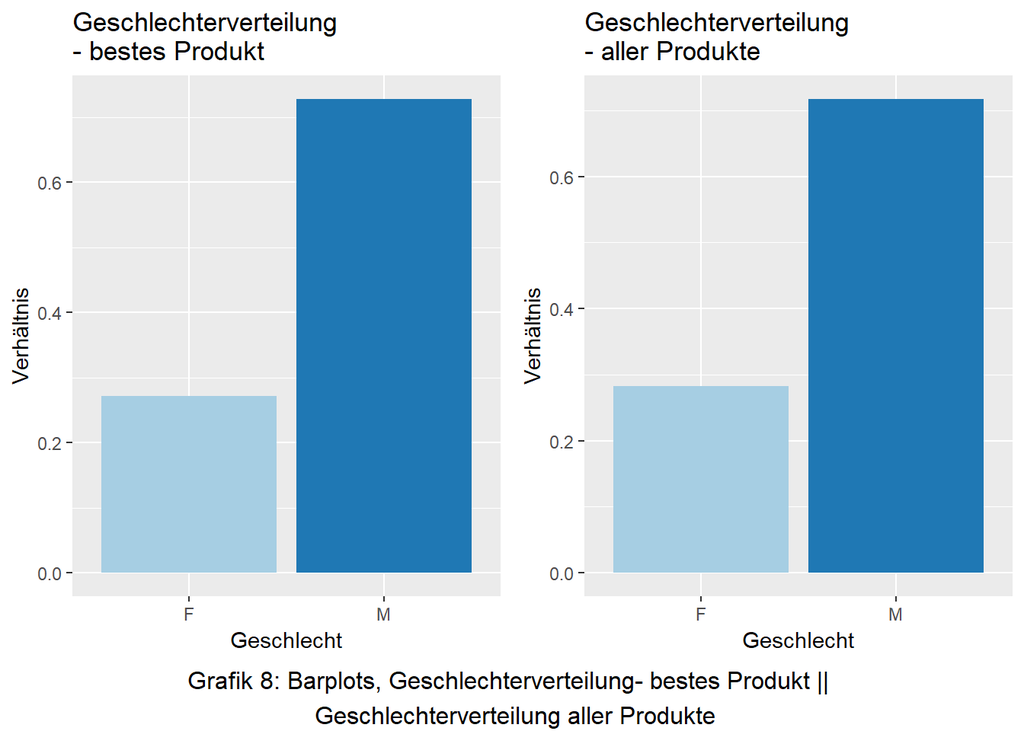

## Berufsgruppe

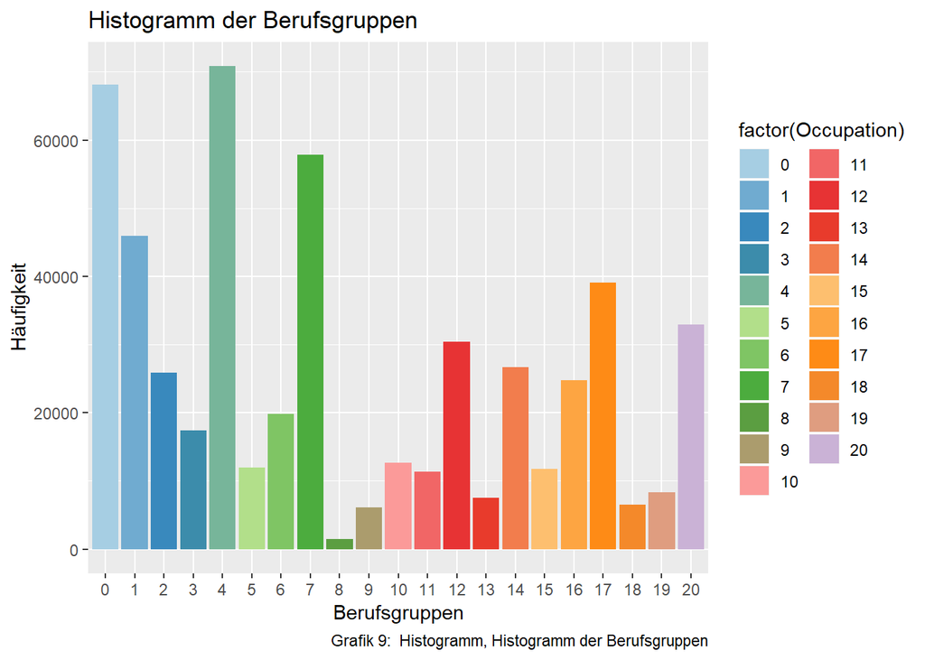

Wir interessieren uns für die Summe der Einkäufe der einzelnen Berufsgruppen:

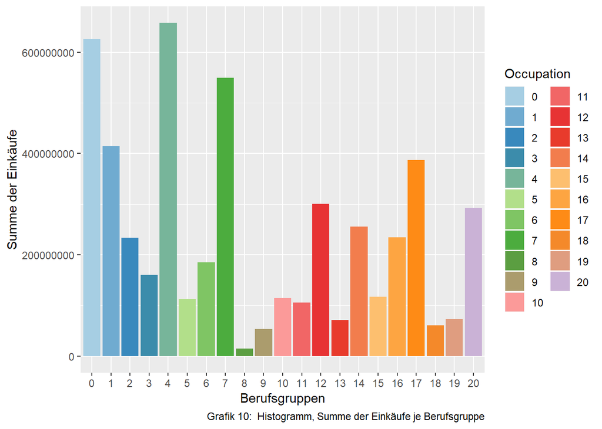

Die Summe der Einkäufe ist bei der Berufsgruppe 0, 4 und 7 am höchsten. Daraus lässt sich ableiten, dass die Berufsgruppen die am häufigsten vertreten sind, auch am meisten einkaufen. Da keine Informationen zu der Bedeutung der Zahlen der Berufsgruppen vorhanden sind, ist der Informationsgehalt der obigen Grafik (`Grafik 10: Histogramm, Summe der Einkäufe je Berufsgruppe`) eher gering.

Wir insteressieren uns dafür, wie die einzelne Verteilung der Produkt Kategorien zwischen männlichen und weiblichen Kunden aussieht, bzw. ob Kategorie 2 und 3 von Männern oder Frauen öfters gekauft wurde.

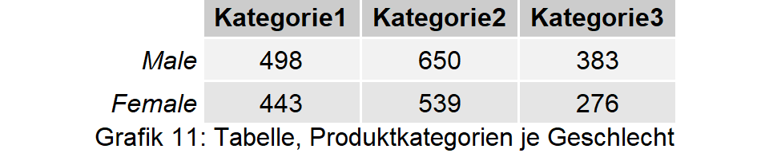

Im Durchschnitt kaufen Männer in allen 3 Kategorien mehr ein (jeweils 12%, 20%, 38% mehr). Wir interpretieren daraus, dass die Produkte generell mehr mänliche Kunden anspricht. Speziell Kategorie 2 und 3 wurde gehäuft von Männern eingekauft und könnte ein Indiz dafür sein, dass die Zielgruppe für Kat 2 und 3 eher die Männer sind.

## Alter

Als nächsten betrachten wir das Alter unserer Kunden in einer Tabelle:

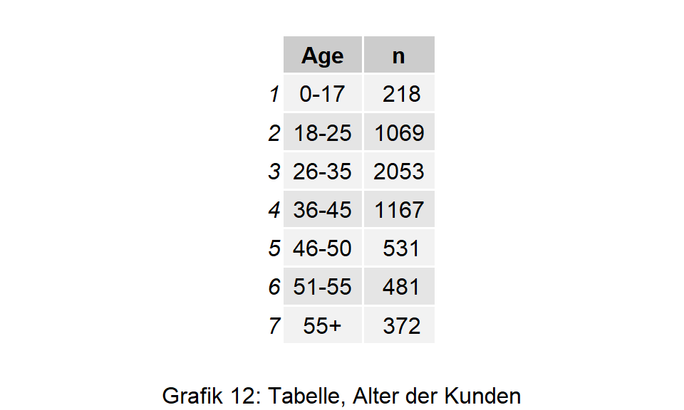

Geplottet sieht die Verteilung folgendermaßen aus:

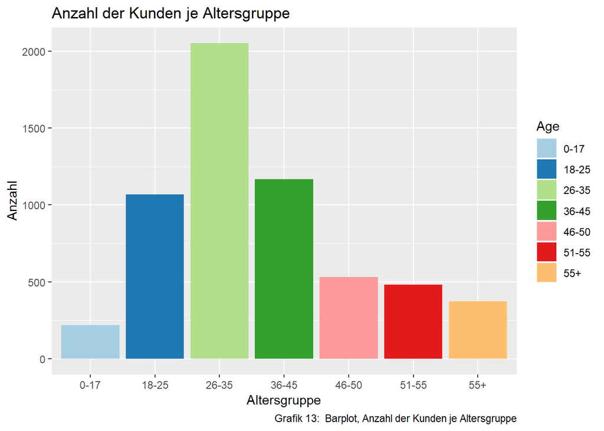

In der Grafik (`Grafik 13: Barplot, Anzahl der Kunden je Altersgruppe`) wird ersichtlich, dass die meisten Käufer zwischen 26-35 und 36-45 Jahre alt sind.

## Wohnort

In diesem Teil beschäftigen wir uns mit der Analyse des Wohnortes unserer Kunden und gehen auf folgende Fragen ein:

- Wo leben unsere Kunden?
- Welche Kunden generieren den größten Umsatz?
- Welche Kunden generieren den größten Absatz?
- Wieviel trägt das Best-Verkaufste Produkt zu dem Gesamtumsatz in einem Wohnort bei?

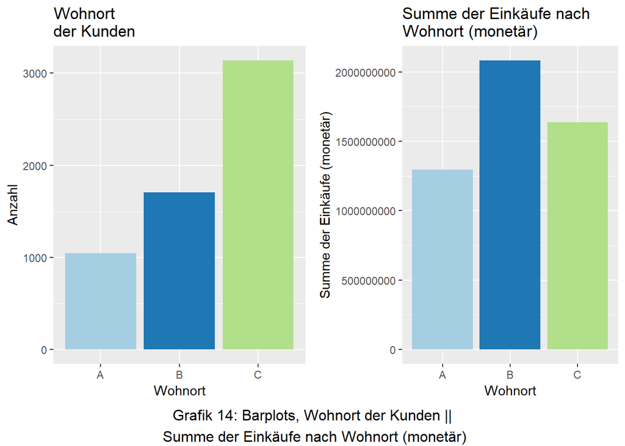

Obwohl die meisten Kunden aus `Wohnort C` stammen, haben die Kunden aus `Wohnort B` in Summe deutlich mehr für ihre Einkäufe ausgegeben, was anhand der oberen Grafiken (`Grafik 14: Barplots, Wohnort der Kunden || Summe der Einkäufe nach Wohnort (monetär)`) ersichtlich ist.

Im Weiteren wollen wir uns näher mit eben diesem Phänomen beschäftigen, dazu betrachten wir die Anzahl der Artikel die in den Wohnorten erstanden hat.

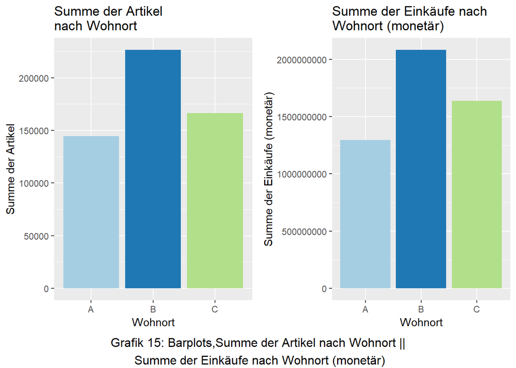

Aus der oberen Gegenüberstellung ist ersichtlich dass der `Wohnort B` am meisten Waren an diesem Tag umgesetz hat. Dies spiegelt sich auch in den Summen aller Einkäufe im Bezug zu den Wohnorten wieder. Damit kann nicht behauptetet werden dass Die Kunden aus `Wohnort B` ausschließlich hochpreisige Produkte gekauft hätten, das beobachtete Peak wäre auch zu erklären wenn die Kunden eine größere Anzahl an Waren umgesetzt hätten.

Im weiteren Verlauf wollen wir nun das best-verkaufteste Produkt je Wohnort ermitteln. Dazu greifen wir auf die bereits existierende Information “bestes_Produkt” zurück.

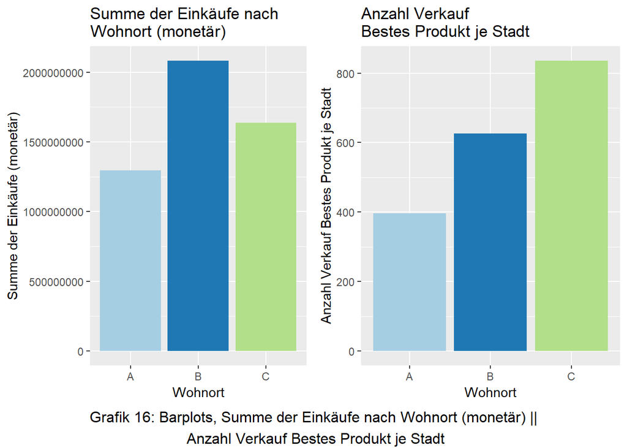

Mit der oberen Auswertung ist ersichtlich, dass zwar `Wohnort B` den meisten Usatz generiert. Dennoch wird das best-verkaufteste Produkt unerwarteterweise am Häufigsten in `Wohnort C` verkauft.

## Kunden an einem spezifischem Wohnort

Im nächsten Schritt analysieren wir die Kundengruppe und der Aufenthalt am gegenwärtigen Wohnort genauer. Diese Information kann als Grundlage für die Analyse welche Produkte welchem Kunden in welcher Lebenssituation am besten vorgeschlagen werden verwendet werden. Dazu betrachten wir zunächst wielange alle unsere Kunden an Ihrem gegenwärtigen Wohnistz leben:

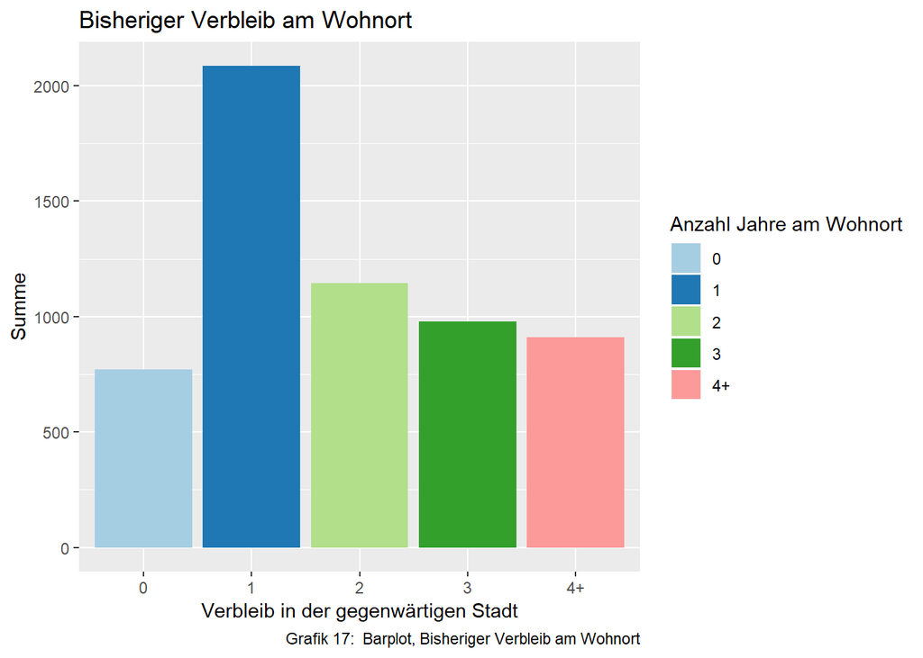

Anhand der oberen Grafik (‘Grafik 17: Barplot, Bisheriger Verbleib am Wohnort’) ist abzulesen, dass die meisten Kunden an ihrem jeweiligen Standort gegenwärtig 1 Jahr leben, jedoch bezieht sich diese Inforamtion auf alle drei Wohnorte kummoliert. Eine Erklärung wäre, dass alle drei Wohnorte vor einem Jahr eine einen starken “Zuzug” erlebt hatten. Eine alternative Interpretation kann aber auch sein, dass in diesen Wohnorten die meisten Bürger nach einem Jahr erneut umziehen. Dies ist jedoch mit den gegebenen Daten nicht eindeutig bestimmbar.

Dennoch analysieren wir das obere Phänomen etwas granularere betrachten indem wir den Verbleib am bisherigen Wohnort nach den Städten aufteilen

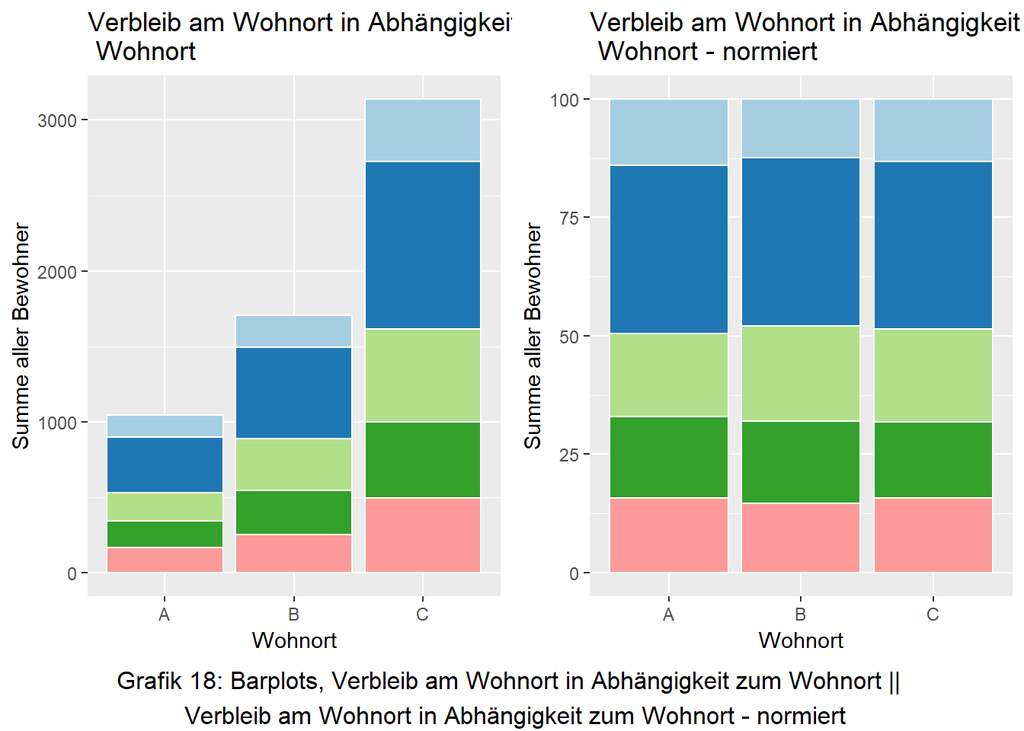

Bei der Betrachtung der oberen Plots (`Grafik 18`) erkennen wir in der linken Grafik die tiefere Betrachtung der bereits behandelten „Wohnort der Kunden“. Hierbei haben wir nun die einzelnen Wohnorte weiter nach den Untergruppen des Verbleibes in den Standorten aufgeteilt. Es ist zu erkennen das der Größte Wohnort C in allen Verbleibs-Gruppen ebenfalls die größten Ausprägungen aufweist. In der rechten Grafik werden die relativen Anteile der Verbleibs-Gruppen in einem Wohnort dargestellt. Hierbei ist zu erkennen, dass die jeweiligen Gruppen über alle betrachteten Wohnorte hinweg in etwa gleich ausgeprägt sind.

Somit können wir aussagen, dass sich die Wohnorte sich in ihrer absoluten Ausprägung deutlich unterscheiden(Wohnort C ist dreimal so groß wie Wohnort A). Die Größe eines Wohnortes hat in unserem Vergleich der drei Standorte aber keine Auswirkung auf die Verweildauer einer Person an diesen Standorten.

# Feature Engineering

Wir schauen uns nochmal die Struktur der Daten an. Dabei fällt uns auf, dass manche Features noch nicht im richtigen Format sind.

```
## 'data.frame':    537577 obs. of  12 variables:
##  $ User_ID                   : int  1000001 1000001 1000001 1000001 1000002 1000003 1000004 1000004 1000004 1000005 ...
##  $ Product_ID                : Factor w/ 3623 levels "P00000142","P00000242",..: 671 2375 851 827 2733 1830 1744 3319 3597 2630 ...
##  $ Gender                    : Factor w/ 2 levels "F","M": 1 1 1 1 2 2 2 2 2 2 ...
##  $ Age                       : Factor w/ 7 levels "0-17","18-25",..: 1 1 1 1 7 3 5 5 5 3 ...
##  $ Occupation                : int  10 10 10 10 16 15 7 7 7 20 ...
##  $ City_Category             : Factor w/ 3 levels "A","B","C": 1 1 1 1 3 1 2 2 2 1 ...
##  $ Stay_In_Current_City_Years: Factor w/ 5 levels "0","1","2","3",..: 3 3 3 3 5 4 3 3 3 2 ...
##  $ Marital_Status            : int  0 0 0 0 0 0 1 1 1 1 ...
##  $ Product_Category_1        : int  3 1 12 12 8 1 1 1 1 8 ...
##  $ Product_Category_2        : int  0 6 0 14 0 2 8 15 16 0 ...
##  $ Product_Category_3        : int  0 14 0 0 0 0 17 0 0 0 ...
##  $ Purchase                  : int  8370 15200 1422 1057 7969 15227 19215 15854 15686 7871 ...
```

Im folgenden restrukturieren wir unsere Daten. Die meisten Prädiktoren werden zu faktorielle Variablen umgewandelt. Die Produktkategorien werden als Integer belassen.

```r
bf$User_ID <- as.factor(bf$User_ID)
bf$Occupation <- as.factor(bf$Occupation)
bf$Marital_Status <- as.factor(bf$Marital_Status)
str(bf)
```

```
## 'data.frame':    537577 obs. of  12 variables:
##  $ User_ID                   : Factor w/ 5891 levels "1000001","1000002",..: 1 1 1 1 2 3 4 4 4 5 ...
##  $ Product_ID                : Factor w/ 3623 levels "P00000142","P00000242",..: 671 2375 851 827 2733 1830 1744 3319 3597 2630 ...
##  $ Gender                    : Factor w/ 2 levels "F","M": 1 1 1 1 2 2 2 2 2 2 ...
##  $ Age                       : Factor w/ 7 levels "0-17","18-25",..: 1 1 1 1 7 3 5 5 5 3 ...
##  $ Occupation                : Factor w/ 21 levels "0","1","2","3",..: 11 11 11 11 17 16 8 8 8 21 ...
##  $ City_Category             : Factor w/ 3 levels "A","B","C": 1 1 1 1 3 1 2 2 2 1 ...
##  $ Stay_In_Current_City_Years: Factor w/ 5 levels "0","1","2","3",..: 3 3 3 3 5 4 3 3 3 2 ...
##  $ Marital_Status            : Factor w/ 2 levels "0","1": 1 1 1 1 1 1 2 2 2 2 ...
##  $ Product_Category_1        : int  3 1 12 12 8 1 1 1 1 8 ...
##  $ Product_Category_2        : int  0 6 0 14 0 2 8 15 16 0 ...
##  $ Product_Category_3        : int  0 14 0 0 0 0 17 0 0 0 ...
##  $ Purchase                  : int  8370 15200 1422 1057 7969 15227 19215 15854 15686 7871 ...
```

Die nicht-nummerischen Variablen Gender und City-Category werden in Dummy-Variablen codiert. Die ursprünglichen Variablen `Gender`und `City_Category` werden entfernt.

```r
bf_cor <- bf
bf_cor <- fastDummies::dummy_cols(bf_cor, select_columns = c("Gender", "City_Category"))
bf_cor$Gender = NULL
bf_cor$City_Category = NULL
```

## Visualisierung der Korrelationen anhand der Heatmap

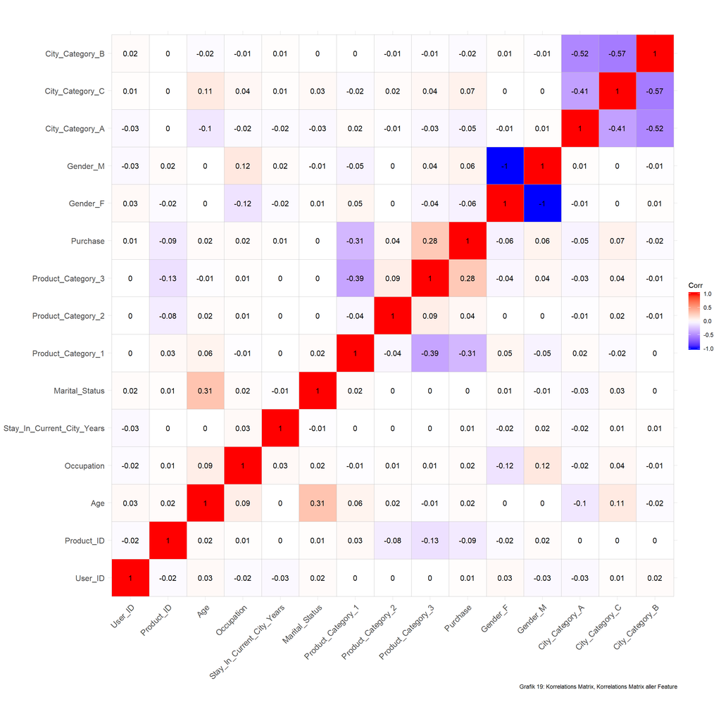

```r
bf_int <- bf_cor
bf_int[] <- lapply(bf_int,as.integer)
cormat <- round(cor(bf_int),2)
ggcorrplot(cormat, lab=T) + labs(
       caption = "Grafik 19: Korrelations Matrix, Korrelations Matrix aller Feature")
```

In unserem Datensatz finden wir nur sehr schwache Korrelationen zwischen unseren Variablen. Die Variablen `Gender_M`und `Gender_F` korrelieren selbstverständlich negativ, da sie sich von Natur aus ausschließen. Eine schwache positive Korrelation ist zwischen `Purchase` und `Product_Category_3` zu erkennen, was uns sagt, dass mehr Geld für Produkt 3 ausgegeben wurde. Umgekehrt haben wir eine schwache negative Korrelation zwischen zwischen ‘Purchase’ und `Product_Category_1`, also weniger Geld das für Produkt 1 ausgegeben wurde. Es könnte entweder bedeuten, dass Produkte der Kategorie 3 einfach teurer sind als Produkte der Kategorie 1 oder, dass Produkte der Kategorie 3 öfter gekauft wurden als die der Kategorie 1. Auch zu erkennen ist die schwache negative Korrelation zwischen Kategorie 1 und 3, was darauf schließen lässt, dass wenn Produkte aus Kategorie 1 gekauf wurden, wurden eher weniger Produkte der Kategorie gekauft. Auch weisen die `City_Category A, B, C` untereinander negative Korrelationen auf, die für uns nicht weiter wichtig sind. Die schwache Korrelation zwischen Alter und Ehestatus (z.B. ältere Leute sind eher verheiratet) ist aufgrund sozialer Eigenschaften erklärt und für uns uninteressant.

## Skalierung

```r
max_data = apply(bf_int,2,max)
min_data = apply(bf_int,2,min)

scaled = data.frame(scale(bf_int, center=min_data, scale=max_data-min_data))
summary(scaled)
```

```
##     User_ID         Product_ID          Age           Occupation
##  Min.   :0.0000   Min.   :0.0000   Min.   :0.0000   Min.   :0.0000
##  1st Qu.:0.2462   1st Qu.:0.2559   1st Qu.:0.3333   1st Qu.:0.1000
##  Median :0.5008   Median :0.4544   Median :0.3333   Median :0.3500
##  Mean   :0.4945   Mean   :0.4672   Mean   :0.4158   Mean   :0.4041
##  3rd Qu.:0.7307   3rd Qu.:0.6996   3rd Qu.:0.5000   3rd Qu.:0.7000
##  Max.   :1.0000   Max.   :1.0000   Max.   :1.0000   Max.   :1.0000
##  Stay_In_Current_City_Years Marital_Status   Product_Category_1
##  Min.   :0.0000             Min.   :0.0000   Min.   :0.0000
##  1st Qu.:0.2500             1st Qu.:0.0000   1st Qu.:0.0000
##  Median :0.5000             Median :0.0000   Median :0.2353
##  Mean   :0.4649             Mean   :0.4088   Mean   :0.2527
##  3rd Qu.:0.7500             3rd Qu.:1.0000   3rd Qu.:0.4118
##  Max.   :1.0000             Max.   :1.0000   Max.   :1.0000
##  Product_Category_2 Product_Category_3    Purchase         Gender_F
##  Min.   :0.0000     Min.   :0.0000     Min.   :0.0000   Min.   :0.0000
##  1st Qu.:0.0000     1st Qu.:0.0000     1st Qu.:0.2389   1st Qu.:0.0000
##  Median :0.2778     Median :0.0000     Median :0.3313   Median :0.0000
##  Mean   :0.3769     Mean   :0.2151     Mean   :0.3848   Mean   :0.2459
##  3rd Qu.:0.7778     3rd Qu.:0.4444     3rd Qu.:0.5000   3rd Qu.:0.0000
##  Max.   :1.0000     Max.   :1.0000     Max.   :1.0000   Max.   :1.0000
##     Gender_M      City_Category_A  City_Category_C  City_Category_B
##  Min.   :0.0000   Min.   :0.0000   Min.   :0.0000   Min.   :0.0000
##  1st Qu.:1.0000   1st Qu.:0.0000   1st Qu.:0.0000   1st Qu.:0.0000
##  Median :1.0000   Median :0.0000   Median :0.0000   Median :0.0000
##  Mean   :0.7541   Mean   :0.2691   Mean   :0.3096   Mean   :0.4213
##  3rd Qu.:1.0000   3rd Qu.:1.0000   3rd Qu.:1.0000   3rd Qu.:1.0000
##  Max.   :1.0000   Max.   :1.0000   Max.   :1.0000   Max.   :1.0000
```

Ebenso implementieren wir in unserem Data Pre-Processing eine Skalierung mittels MaxMin-Scaling. Wir skalieren unsere Daten um diese auf ein gleichen Skalenniveau zu bringen und um die Feature miteinandern vergleichbar zu machen. Als Resulat unseres Scalings sind in unserem Datensatz lediglich Werte zwischen 0 und 1 in unserem Scaled-Data-Set. Bei späteren Prognosen müssen diese wieder reskaliert werden.

Ein einfacher Scatterplot codiert nach männlichen und weiblichen Customern zeigt, dass das Volumen der einzelnen Einkaeufe realtiv uniform verteilt ist mit deutlichen Clusterin im hoch-preisigen Segment.

[figure not shown]

Eine der Annahmen fuer ein lineares Regressionsmodell ist die Normalverteilung der Residuen. Dafuer wird das Histogram der dependent Variable Purchase betrachtet:

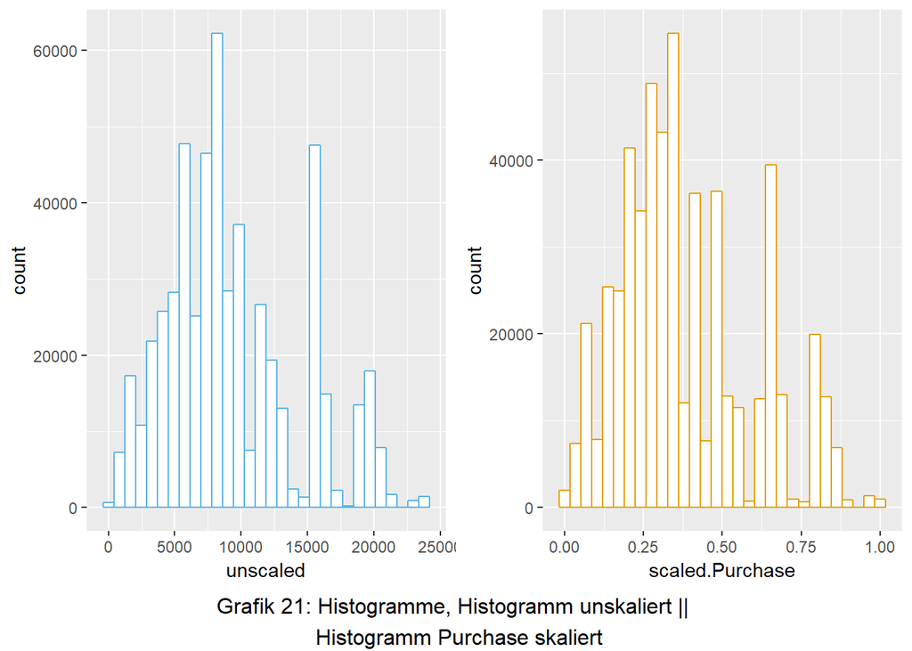

Für die Überprüfung auf Normalverteilung mithilfe des Shapiro-Wilk Test ist die Sample Size zu groß ist bzw. der Chi-Quadrat Test nur für kategoriale Variablen anwendbar. Auch ein nicht-parametrischer Test wie Kolmogorov-Sminrov Test kommt nicht infrage, da bei einer so großen Sample Size immer die Null-Hypothese abgelehnt werden würde. Deshalb kann hier gemäß des zentralen Grenzwertsatzes Normalverteilung angenommen werden.

```r
bf <- bf[sample(nrow(bf), 20000), ]
```

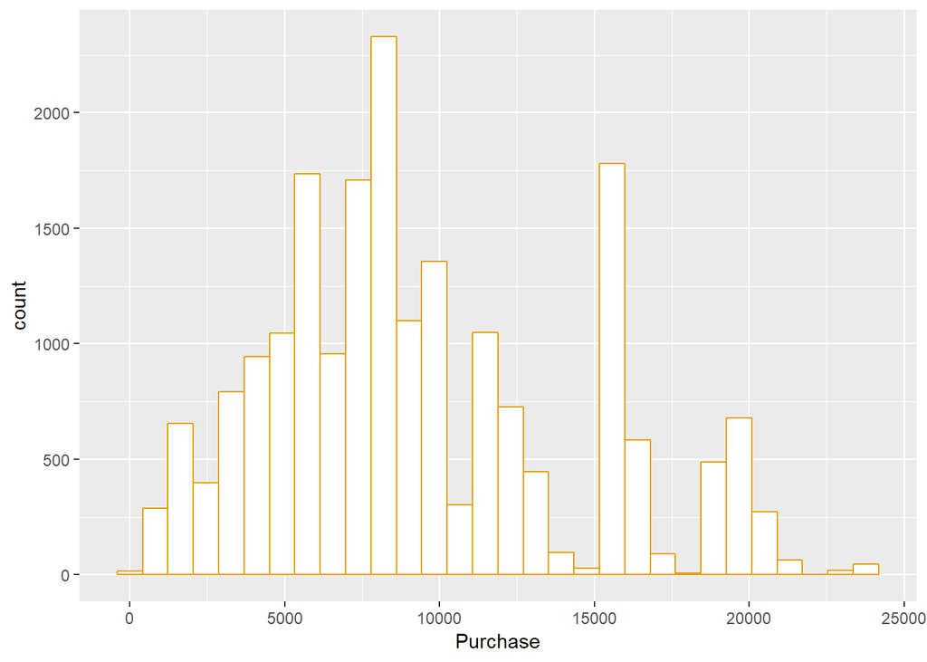

## Train Test Split

Im Folgenden unterteilen wir den Datensatz in Training und Test Daten. 70% werden als Trainingsdaten zugeteilt, damit ausreichend viele Beobachtungen im späteren Training verarbeitet werden können. 30% werden den Testdaten zugeteilt, um ein repräsentatives Testszenario zu bilden. Wir müssen die Trainingsdaten zu einem guten Train- TestSplit aufteilen, damit wir einerseits für das Training ausreichend viele, verschiedene und representative Samples verarbeiten und das Modell daraus die unterschiedlichen Charakteristika erlernt und auf untrainierte Daten gut generalisieren kann. Diese Generalisierung testen wir mit den Testdaten. Diese müssen auch wieder ausreichen vielfältig sein und die Stichprobe gut repräsentieren können. Aus diesem Grund wählen wir 30% aus der Gesamtpopulation und weisen sie dem Testdatensatz zu. Somit können wir sicher sein, dass die Ergebnisse durch das Testen akkurat sind und in Verwendung zusätzlicher real-world Samples gut generalisiert.

```r
options(scipen=999)
index <- createDataPartition(
  y = bf$Purchase,
  ## Purchase ist dependent Variable
  p = .7,
  ##  Verhaeltnis traing - test set
  list = FALSE
)
training <- bf[ index,]
testing  <- bf[-index,]
```

# Modellierung des Sales Volumen

Für Werbetreibende ist besonders interessant, ihre Kunden gezielt mit Werbung zu bespielen, die auf die jeweilige demographische Gruppe angepasst ist. Werden Werbeanzeigen z.B. bei Google oder Instagram gekauft, kann genau definiert werden, welchem Kundensegment die Werbung angezeigt werden soll (z.B. nur Frauen zwischen 18 und 24). Damit schon vor Schalten der Werbung untersucht werden kann, welche Kunden besonders kauffreudig sind, soll der Preis, für den der jeweilige Kunde einkaufen wird, vorausgesagt werden mithilfe eines statistischen Modells.

## Lineare Regression mit Resampling

```r
##Modell mit Resampling

##resampling
ctrl <- trainControl(method = "repeatedcv", repeats = 5)

## Model Fitting
model_lin_regression <- train(
  Purchase ~ .,
  data = training,
  method = "lm",
  preProc = c('center', 'scale'),
  tuneLength = 15,
  na.action = na.pass,
  trControl = ctrl
)

#Anzeigen finales Modell
model_lin_regression$finalModel

#Prediction mit Testing Data
pred_lin_regression <- unname(predict(model_lin_regression, testing))
#RMSE
lin_model_rmse <- RMSE(testing$Purchase,pred_lin_regression)
lin_model_rmse
```

[output not shown]

Zum Vergleich aller Modelle wird der RMSE gewählt, daher werden große Errors relativ stark gewichtet. Der RMSE ist ziemmlich hoch. Dieser Wert soll nun in den folgenden Modellen verbessert werden.

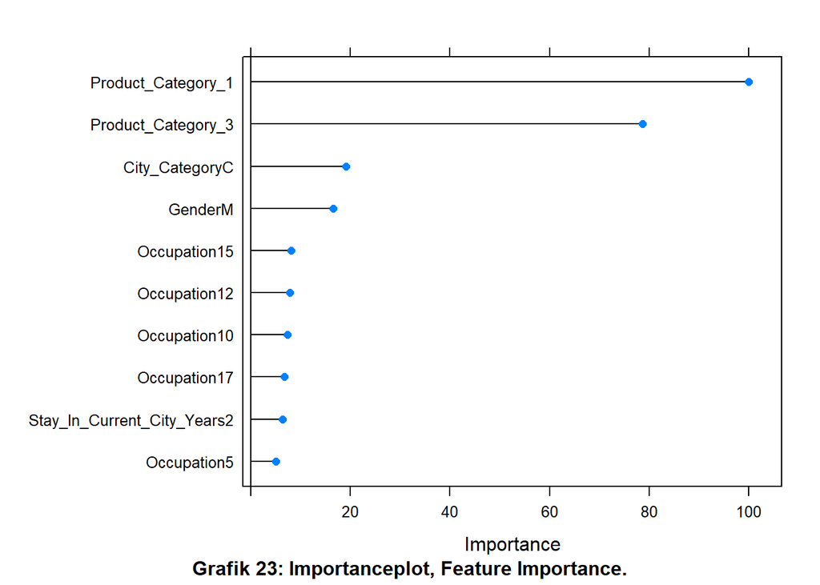

## Random Forest Regression (mit Resampling)

Für das folgende Modell wird ein Random Forest gefittet. Es wird derselbe Trainings- und Test-Datensatz verwendet.

```r
#Tuning Grid
tune.grid <- seq(1,101, by=2)
tune <- expand.grid(mtry = 1:10)

#Random Forest Model
model_RF <- train(
  Purchase ~ .,
  data = training,
  method = "rf",
  preProc = c('center', 'scale'),
  trControl = ctrl,
  na.action = na.pass,
  ntree = 250,
  tuneGrid =tune)

#prediction
pred_RF_test <- predict(model_RF,testing)

#RMSE
RF_rmse_test <- RMSE(testing$Purchase,pred_RF_test)
RF_rmse_test
```

```
## [1] 3163.282
```

Durch dieses Modell konnte der RMSE nochmal um einiges Verbessert werden.

[figure not shown]

```r
plot(model_RF,  sub="Grafik 24: Linienplot, Error über Anzahl der Bäume.")
```

## Modelle fuer einzelne Customer Segmente

Durch die die oben getesteten Modelle konnte die Prediction der Variable `Purchase` zwar verbessert werden, der RMSE ist aber immer noch recht hoch. Deswegen sollen fuer einzelne Customer Segmente jeweils eigene Modelle erstellt werden.

Männliche Customers haben in jeder Altersklasse eine durchschnittlich hoehere Kaufkraft als Frauen (Frauen sind im Datensatz unterrepräsentiert; Verhältnis Männer/Frauen: 4:1,3). Besonders auffallend ist der Peak in der Altergruppe 26-35 bei der Anzahl der Purchases bei männlichen Customers, im Mean, ist dieser allerdings nicht mehr so signifikant, daher es ist mit einer hohen Varianz zu rechnen (siehe Section Despriptive Analyse: Geschlecht).

Im folgenden Modell wird jeweils ein Random-Forest Modell fuer weibliche & männliche Customer erstellt.

```r
#Trainings/Test Split -> subset aus dem originalen Trainings/Test Split
fem_training <- subset(training,Gender == "F")
fem_testing <- subset(testing,Gender == "F")
male_training <- subset(training,Gender == "M")
male_testing <- subset(testing,Gender == "M")
```

```r
#RF Model for Female
RF_female <- train(
  Purchase ~ .,
  data = fem_training,
  method = "rf",
  preProc = c('center', 'scale'),
  trControl = ctrl,
  na.action = na.pass,
  ntree = 250,
  tuneGrid =tune)

#RF Model for Male
RF_male <- train(
  Purchase ~ .,
  data = male_training,
  method = "rf",
  preProc = c('center', 'scale'),
  trControl = ctrl,
  na.action = na.pass,
  ntree = 250,
  tuneGrid =tune)

#Predictions
pred_RF_female <-  predict(RF_female,fem_testing)
pred_RF_male <- predict(RF_male,male_testing)

#RMSE
RF_rmse_female <- RMSE(fem_testing$Purchase,pred_RF_female)
RF_rmse_male <- RMSE(male_testing$Purchase,pred_RF_male)
```

## Evaluierung der Modelle

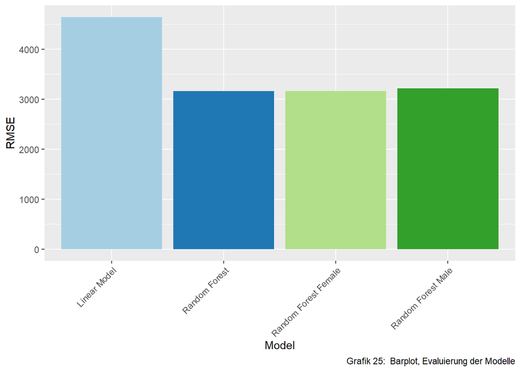

| Model | RMSE |
| --- | --- |
| Linear Model | 4641.751 |
| Random Forest | 3163.282 |
| Random Forest Female | 3161.554 |
| Random Forest Male | 3216.959 |

### Vorhersage für durchschnittlichen Customer

Zuletzt soll noch eine Vorhersage mit einem “durchschnittliche” weibichen & männlcihen Customer getroffen werden. Dafür werden zuerst die Durchschnittswerte für alle numerischen Features ermittelt, alle anderen werden zufällig gewählt.

```r
colnames(pred) <- c("Prediction weiblich", "Prediction männlich")
knitr::kable(pred)
```

| Prediction weiblich | Prediction männlich |
| --- | --- |
| 11749.49 | 6725.483 |

## Multilabel Klassifizierung mit Neuralnet

Betrachten wir nochmals den Scatterplot (`Grafik 20: Scatterplot, Scaterplott der ersten 50000 Instanzen`), fällt uns bei der Variable `Purchase` auf, dass sich harte Grenzen im Bereich zwischen 17800 und 22000 und ab 22000 aufwärts befinden. Die Gaps zwischen den Grenzen scheinen jedoch viel zu sauber zu sein, als dass sie organische Usergruppenverteilung wiederspiegel. Wir nehmen an, dass es sich hierbei um externe Einflüsse, wie beispielsweiße Kaufangebote (Nimm 3, zahle 2), handelt. Durch Angebote im Verkauf wäre eine solche klare Trennung der Käufer nachvolziebar. Würde die Trennung der Kunden rein organisch zustandekommen, dann müssten die Purchases der Kunden nach oben hinweg kontinuierlich, in ihrem Auftreten in der Gesamtstichprobe kontinuierlich abnehmen. Je höher die die Purchase Summe, desto weniger representative Samples.

Für die weitere Herangehensweise in der Klassifizierung wollen wir aber dennoch die Kunden diesen drei Clustern zuordnen. Somit stellen die Cluster Kunden dar, die gering, mittel und sehr viel einkaufen. Der Mobile Game Markt lebt z.B. von den sogenannten ‘Whales’, d.h. Kunden die besonders viel Geld für Ingame-Währungen ausgeben. Daher ist dieses Kundensegment besonders attraktiv. Der Grossteil der Kunden befinden sich im untersten Segment.

Jetzt soll ein Klassifizierungsmodell für die Cluster gefittet werden. Dafür wird als erstes die Variable `Purchase` in 3 Faktoren `low`,`medium`& `high` gebinnt. Im Anschluss wird ein multilable Classification Model mithilfe eines Neural Networks modelliert.

```r
training$Purchase <- cut(training$Purchase,breaks=c(0,17800,22000,max(training$Purchase)),
                         labels = c("low","medium","high"))
testing$Purchase <- cut(testing$Purchase,breaks=c(0,17800,22000,max(testing$Purchase)),
                        labels = c("low","medium","high"))
```

```r
nnmodel <- neuralnet(Purchase.low+Purchase.medium+Purchase.high ~ .,
                      data=data_training,
                      hidden=c(4,3),
                      threshold = 1,
                      act.fct = "logistic",
                      stepmax=1000000)
```

```r
confusionMatrix(actual_value,prediction)
```

```
## Confusion Matrix and Statistics
##
##           Reference
## Prediction  low medium high
##     low    5485     30    0
##     medium  459      9    0
##     high     16      0    0
##
## Overall Statistics
##
##                Accuracy : 0.9158
##                  95% CI : (0.9085, 0.9227)
##     No Information Rate : 0.9935
##     P-Value [Acc > NIR] : 1
##
##                   Kappa : 0.0229
##
##  Mcnemar's Test P-Value : NA
##
## Statistics by Class:
##
##                      Class: low Class: medium Class: high
## Sensitivity              0.9203      0.230769          NA
## Specificity              0.2308      0.922987    0.997333
## Pos Pred Value           0.9946      0.019231          NA
## Neg Pred Value           0.0186      0.994576          NA
## Prevalence               0.9935      0.006501    0.000000
## Detection Rate           0.9143      0.001500    0.000000
## Detection Prevalence     0.9193      0.078013    0.002667
## Balanced Accuracy        0.5755      0.576878          NA
```

```r
table(training$Purchase)
```

```
##
##    low medium   high
##  12911   1041     49
```

Die Verteilung der Faktoren in Purchase zeigt, dass die Kategorie `high` mit nur 49 Instanzen unterrepräsentiert ist. Bei einem balancierten Datensatz, würde man aus jeder Klasse deshalb 49 Instanzen sampeln. Das ist aber für das Training eines NNs viel zu wenig. Deshalb wird wieder auf den gesamten Datensatz zurückgegriffen.

```
##
##    low medium   high
## 494150  41111   2316
```

Jetzt befinden sich 2316 Instanzen in der Kategorie `high`. Deshalb werden aus den beiden anderen Klassen jetzt 2316 Instsanzen gesamplet.

```r
low =  subset(data, data$Purchase=='low')
medium =  subset(data, data$Purchase=='medium')
high =  data.frame(subset(data, data$Purchase=='high'))

low <- data.frame(low[sample(nrow(low), 2316), ])
medium2 <- data.frame(medium[sample(nrow(medium), 2316), ])

nn_data <- bind_rows(low,medium2,high)
table(nn_data$Purchase)
```

```
##
##    low medium   high
##   2316   2316   2316
```

### Trainings/Test Split für NN

```r
index <- createDataPartition(
  y = nn_data$Purchase,
  p = .7,
  list = FALSE)

nn_training <- nn_data[ index,]
nn_testing  <- nn_data[-index,]
```

```r
nnmodel2 <- neuralnet(Purchase.low+Purchase.medium+Purchase.high ~ .,
                      data=data_training,
                      hidden=c(10,10),
                      threshold = 1,
                      act.fct = "logistic",
                      stepmax=1000000)
```

```r
confusionMatrix(actual_value,prediction)
```

```
## Confusion Matrix and Statistics
##
##           Reference
## Prediction low medium high
##     low    494    200    0
##     medium  51    608   35
##     high     0      0  694
##
## Overall Statistics
##
##                Accuracy : 0.8626
##                  95% CI : (0.8471, 0.8771)
##     No Information Rate : 0.3881
##     P-Value [Acc > NIR] : < 0.00000000000000022
##
##                   Kappa : 0.7939
##
##  Mcnemar's Test P-Value : NA
##
## Statistics by Class:
##
##                      Class: low Class: medium Class: high
## Sensitivity              0.9064        0.7525      0.9520
## Specificity              0.8699        0.9325      1.0000
## Pos Pred Value           0.7118        0.8761      1.0000
## Neg Pred Value           0.9633        0.8559      0.9748
## Prevalence               0.2618        0.3881      0.3501
## Detection Rate           0.2373        0.2920      0.3333
## Detection Prevalence     0.3333        0.3333      0.3333
## Balanced Accuracy        0.8881        0.8425      0.9760
```

Die Accuracy mit den Ausbalancierte Klassen ist nun etwas niedriger. Besonders die Klassen `high` und `medium` werden gut klassifiziert, bei der Klasse `low` wird oft als `medium` klassifziert. Zuletzt wird noch gestestet, wiegut das Modell am gesamten Datensatz performt:

```r
confusionMatrix(actual_value,prediction)
```

```
## Confusion Matrix and Statistics
##
##           Reference
## Prediction    low medium   high
##     low    365024 127863   1263
##     medium   3543  35711   1857
##     high        0      0   2316
##
## Overall Statistics
##
##                Accuracy : 0.7498
##                  95% CI : (0.7486, 0.7509)
##     No Information Rate : 0.6856
##     P-Value [Acc > NIR] : < 0.00000000000000022
##
##                   Kappa : 0.2777
##
##  Mcnemar's Test P-Value : < 0.00000000000000022
##
## Statistics by Class:
##
##                      Class: low Class: medium Class: high
## Sensitivity              0.9904       0.21832    0.426049
## Specificity              0.2360       0.98556    1.000000
## Pos Pred Value           0.7387       0.86865    1.000000
## Neg Pred Value           0.9184       0.74245    0.994171
## Prevalence               0.6856       0.30428    0.010112
## Detection Rate           0.6790       0.06643    0.004308
## Detection Prevalence     0.9192       0.07647    0.004308
## Balanced Accuracy        0.6132       0.60194    0.713024
```

Basierend auf dem gesamten Datensatz ist die Accuracy auf 75% gesunken. Unser Modell generalisiert also nicht so gut wie gehofft, wie es uns der vorherige Test gezeigt hat. Gründe dafür könnten die folgenden sein:

1. Die Trainingdaten für das ausbalancierte Training waren zu wenig, um eine gute Generalisierteung zu bewirken. Es spiegelt sich weider, dass `low` sehr oft als `medium` klassifziert wird. Es ist also davon auszugehen, dass die Vielseitigkeit der Daten (`low, medium`) über die geringe Anzahl der Trainingsdaten nicht repräsentiert werden konnte.
2. Das Training war nicht ausreichend genug und das Modell zu schwach, was zum underfitting führte.

Zusätzlich enhielt der gesamte Datensatz wiederum den Anteil aller Trainingsdaten, was unseren Test zur Generalisierung verfälschte. Wir haben, das aber vernachlässigt, da die Anzahl der Trainingsdaten im Vergleich zur ganzen Stichprobe nur 1.3% betrug. Würden wir diese explizit aus diesem Test entfernen, dan würde sich die Accuracy um wenige %% weiter veringern.

### Vorhersage für durchschnittlichen Customer

Wie auch mit dem RF-Gender Modell, wird hier eine beispielhafte Vorhersage mit einem beliebigen “Durchschnitsskunden” durchgeführt.

```r
nn_pred <- predict(nnmodel2,newdata = data_dummies[500,])
colnames(nn_pred) <- c("low", "medium","high")
nn_pred
```

```
##          low        medium        high
## 500 1.000793 -0.0007120513 -0.00690488
```

Der Customer wird also in die Kategorie “low” eingeteilt.

Die Anfangs formulierte Modellierungsfrage konnte anhand von mehreren Modellen beantwortet werden, aufgrund der Verteilung der Daten konnte allerdings keines der obigen Regressionsmodelle eine genaueren Vorhersage des Sales Volumen liefern. Das anfängliche Modell einer lineare Regression konnte durch ein Random Forest Modell sowie durch seperate Modelle fuer männliche und weibliche Customer jedoch verbessert werden. Betrachtet man allerdings das Vorhersage-Problem anstatt als eine Regression als ein Klassifizierungsproblem, kann hier eine Accuracy von über 85% erreicht werden. Die Cluster wurden hier visuell bestimmt. Ein Clustering mithilfe eines Algorithmus z.B. KNN wuerde zu einer schärferen Trennung der Cluster führen. Zur weiteren Segmentierung könnte man zu jedem der Cluster `low`, `medium` & `high` ein eigenes Regressionsmodell fitten.

# Schlusswort

Zusammenfassend kann gesagt werden, dass ein signifikanter Unterschied im Kaufverhalten zwischen männlichen und weiblichen Customern besteht, sowohl in der Wahl der der gekauften Produkte sowie die das Einkaufsvolumen. Nach dem wir unsere Daten deskriptiv analysiert und explorative aufbereitet haben, konnten wir tiefergreifendere Informationen aus unseren Kundendaten beziehen. Diese Projektarbeit gestaltete sich für uns als eine observative Studie. Dabei haben wir `Purchase` als Response-Variable und alle restlichen Features (exkl. `User_ID, Product_ID`) als Prädiktoren ausgewählt. Die erlangten Erkenntnisse ermöglichten es uns, unsere Hyptothese H:“Die Purchases können durch unsere Verkaufsdaten mit guter Genauigkeit vorhergesagt werden.” zu besätigen. Unsere Random Forest Modell (RMSE 3163) performte signifikant besser als unser lineares Modell (RMSE 4641). Weitgehend ist der RMSE vom Datensatz abhängig, welcher in unserem Fall sehr unbalanciert ist und, dahergehend die Vorhersagegenauigkeit limitiert.

# Weitere Herangehensweise

Unsere weitere Herangehensweise wäre drei individuelle Trainingsdatensätze aus den drei Clustern (`high, medium, low`) zu samplen. Dadurch könnten wir Random Forest Modelle trainieren die darauf spezialisiert sind, die Purchases der jeweiligen Cluster best möglich vorherzusagen. Unsere Vermutung ist, dass sich der RMSE dadurch noch weiter senken ließe, indem wir Testdaten zuerst über das Neuronale Netzwerk in die drei Cluster (`high, medium, low`) klassifizieren und dann dem entsprechenden Random Forest Modell (trainiert auf Cluster `high, medium, low`) übergeben. Aus unserer Sicht hätte das jedoch den Scope dieses Projektes überschritte und wir beschlossen uns diese Idee gedanklich durchzuspielen aber nicht umzusetzen.